# Reproducible Research: Peer Assessment 1

prepared by: CY Ting

## Loading and preprocessing the data

The loading process begins with loading all the required libraries:

```r
library(data.table)
library(ggplot2)
library(lubridate)
library(lattice)
```

The next steps is to read the file

```r
dt<-fread("activity.csv")
dt$date<-as.Date(dt$date,"%Y-%m-%d")
```

## What is mean total number of steps taken per day?

Extracting the total number of steps grouped by date

```r
dt.sum.date = dt[, total_steps:= sum(steps, na.rm = T),by = date]
```

Histogram showing the total number of steps taken each day

```
## stat_bin: binwidth defaulted to range/30. Use 'binwidth = x' to adjust this.
```

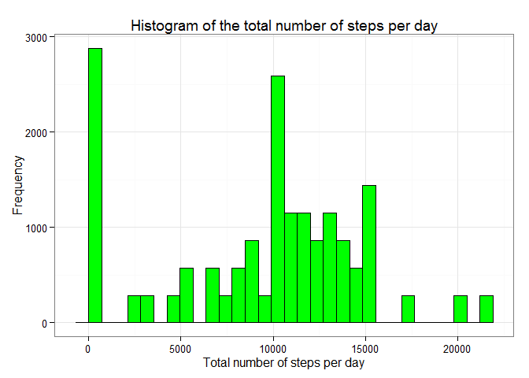

```r
ggplot(dt.sum.date, aes(x=total_steps)) +
     geom_histogram(colour="black", fill="green") +
     labs(x="Total number of steps per day",y="Frequency",
          title="Histogram of the total number of steps per day")+
     theme_bw()
```

The mean and median of total steps per day

```r
mean(dt.sum.date$total_steps)
```

```
## [1] 9354.23
```

```r
median(dt.sum.date$total_steps)
```

```
## [1] 10395
```

## What is the average daily activity pattern?

```r
dt.mean.interval = dt[, mean_steps:= mean(steps, na.rm = T),by = interval]
```

Line graph for average steps for each interval

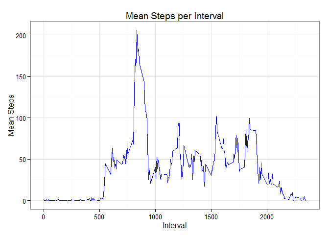

```r
ggplot(data=dt.mean.interval, aes(x=interval, y=mean_steps))+
     geom_line(col="blue")+
     labs(x="Interval",y="Mean Steps",title="Mean Steps per Interval")+
     theme_bw()
```

Identifying the interval with maximum number of steps

```r
dt.mean.interval[which.max(dt.mean.interval$mean_steps)]
```

```
##    steps       date interval total_steps mean_steps
## 1:    NA 2012-10-01      835           0   206.1698
```

A vertical line at max value

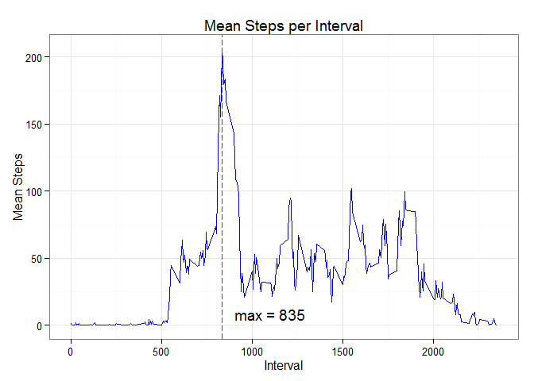

```r
ggplot(data=dt.mean.interval, aes(x=interval, y=mean_steps))+
     geom_line(col="blue")+
     labs(x="Interval",y="Mean Steps",title="Mean Steps per Interval")+
     geom_vline(xintercept = 835, colour="red", linetype = "longdash")+
     annotate("text", x = 1100, y = 8, label = "max = 835")+
     theme_bw()
```

## Imputing missing values

The first step is to identify the number of NA in the Activity dataset.

```r
cat(nrow(dt[is.na(dt$steps),]))
```

```
2304
```

Second, calculate the mean step for each month.

```r
dt.meansteps.month<-dt[,mean(steps,na.rm=TRUE),by=month(date)]
```

Assigning NA with randomly assigned value between 30 to 45. The reason is that the mean for the months is centering around 37. Random sampling would be a better representation for the missing values.

```r
dt.no.missing<-copy(dt)

set.seed(1)
for(i in 1:nrow(dt)){
     if(is.na(dt.no.missing$steps[i])){
          dt.no.missing$steps[i]<-sample(30:45,1)
     }
}
```

The sum of steps per day - after removing missing values

```r
dt.sum.date.no.missing<-dt.no.missing[, total_steps:= sum(steps), by=date]
```

The mean and median of total steps per day

```r
mean(dt.sum.date.no.missing$total_steps)
```

```
## [1] 10766.34
```

```r
median(dt.sum.date.no.missing$total_steps)
```

```
## [1] 10765
```

Histogram for total steps for each date after removing the missing values

```
## stat_bin: binwidth defaulted to range/30. Use 'binwidth = x' to adjust this.
```

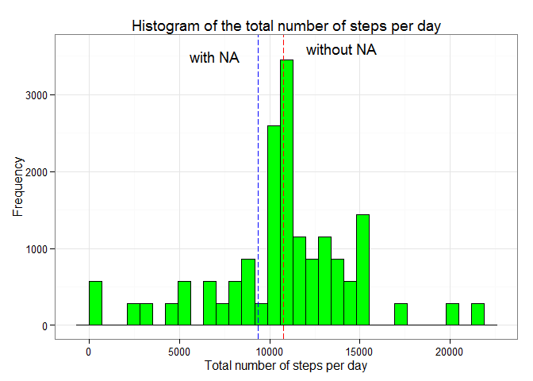

```r
ggplot(dt.sum.date.no.missing, aes(x=total_steps)) +
     geom_histogram(colour="black", fill="green") +
     labs(x="Total number of steps per day",y="Frequency",
          title="Histogram of the total number of steps per day")+
     geom_vline(xintercept = mean(dt.sum.date$total_steps), colour="blue",
                linetype = "longdash")+
     annotate("text", x = 7000, y = 3500, label = "with NA")+
     geom_vline(xintercept = mean(dt.sum.date.no.missing$total_steps),
                colour="red", linetype = "longdash")+
     annotate("text", x = 14000, y = 3600, label = "without NA")+
     theme_bw()
```

## Are there differences in activity patterns between weekdays and weekends?

First, assign names of weekday to a variable named “weekdays”

```r
weekdays <- c("Monday", "Tuesday", "Wednesday", "Thursday", "Friday")
```

Check if a particular date falls under weekdays

```r
dt.no.missing$dayType = as.factor(ifelse(is.element(weekdays(as.Date(dt.no.missing$date)),
                                                    weekdays),
                                         "Weekday", "Weekend"))
```

plotting the xyplot for comparing weekdays and weekends

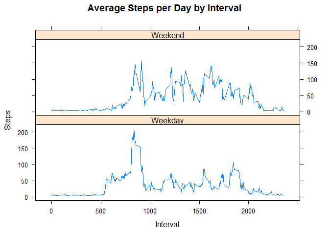

```r
steps.interval <- aggregate(steps ~ interval + dayType, dt.no.missing, mean)

xyplot(steps.interval$steps ~ steps.interval$interval|steps.interval$dayType,
       main="Average Steps per Day by Interval",
       xlab="Interval",
       ylab="Steps",layout=c(1,2), type="l")
```